# Recalling Words

```r
# Play the chunk above and this one to get the data into your Console
View(Friendly)
?Friendly
```

### Background

Many teachers and other educators are interested in understanding how to best deliver new content to students. In general, they have two choices of how to do this.

1. The Meshed Approach
   - Deliver new content while simultaneously reviewing previously understood content.
2. The Before Approach
   - Deliver new content after fully reviewing previously understood content.

A study was performed to determine whether the *Meshed* or *Before* approaches to delivering content had any positive benefits on memory recall.

##### The Experiment (click to view)

### Hypothesis

In this specific situation I want to see whether the the **“Before”** method worked better than the randomly place words, to show whether the this method has any benefits over the plain random method.

Formally, the null and alternative hypotheses are written as
$$H_0: \text{median of the differences} = 0$$

$$H_a: \text{median of the differences} > 0$$
The significance level for this study will be set at
$$\alpha = 0.05$$
### Peek at the Data

```r
datatable(Friendly2, options=list(lengthMenu = c(3,10,30),scrollY=300,scroller=TRUE,scrollX=TRUE),
            extensions="Scroller")
```

|  | condition | correct |
| --- | --- | --- |
| 1 | SFR | 39 |
| 2 | SFR | 25 |
| 3 | SFR | 37 |
| 4 | SFR | 25 |
| 5 | SFR | 29 |
| 6 | SFR | 39 |
| 7 | SFR | 21 |
| 8 | SFR | 39 |
| 9 | SFR | 24 |
| 10 | SFR | 25 |

[output cut: 10 more lines]

The data set above displays the information within this data set.

### Dot Plot Comparison

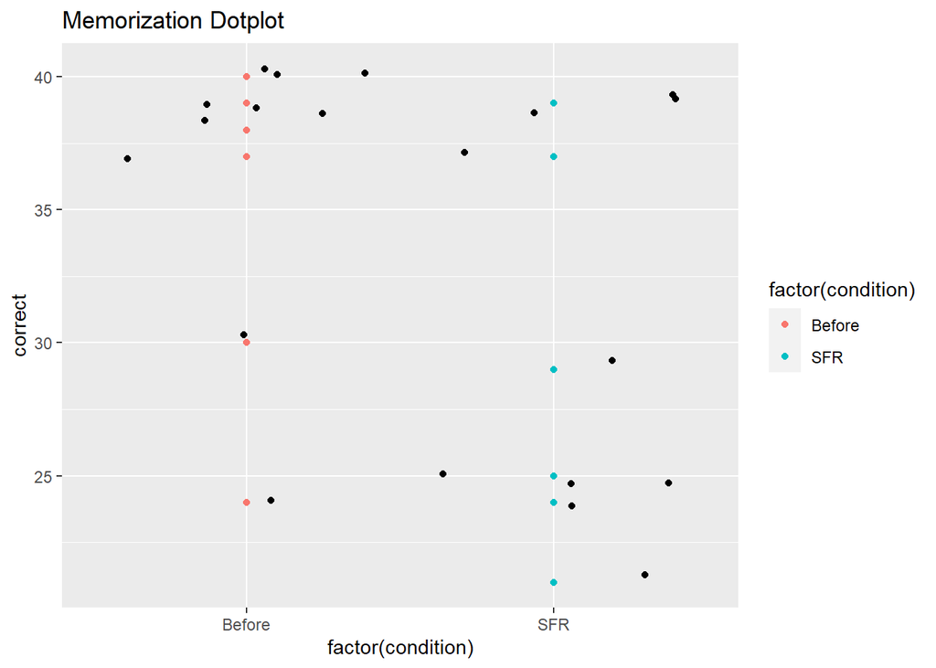

```r
ggplot(Friendly2,aes(factor(condition),correct)) + geom_jitter()+
  geom_point(aes(color=factor(condition)),position=position_dodge(width=0.5)) + labs(title= "Memorization Dotplot")
```

From this graph you can see that the distribution of the points in the data set showing that the *Before* values look to generally be in the higher end of correct words, while the *SFR* section seems to be all over the place.The black dots around each section are to create a better view of the data points.

### Numerical Summaries

```r
stats <- Friendly2 %>%
  group_by(condition) %>%
  summarise(Min = min(correct),
            Q1 = quantile(correct, 0.25),
            Mean = mean(correct),
            Median= median(correct),
            Q3 = quantile(correct, 0.75),
            Max = max(correct),
            "Size" = n(),
            "Standard Dev" = sd(correct)) %>%
  pander()
stats
```

| condition | Min | Q1 | Mean | Median | Q3 | Max | Size | Standard Dev |
| --- | --- | --- | --- | --- | --- | --- | --- | --- |
| Before | 24 | 37.25 | 36.6 | 39 | 39.75 | 40 | 10 | 5.337 |
| SFR | 21 | 25 | 30.3 | 27 | 38.5 | 39 | 10 | 7.334 |

The summary table above shows some summary statistics of the values so we can better idea of the actual number values. We can tell from the values that the **Before** method seems to have a spread that is tighter according to the standard distribution $(\sigma_{before} = 5.337)$. Looking at the minimums and quantiles as well as the maximums we can see that the distribution seems to be in higher ranges of score.

### Addressing Normality

Revisitng the numerical summary above you can see that there is a sample size of 20 data points which is above 10 shy of using the central limit theorm which allows us to assume normality of means which is not the case here.

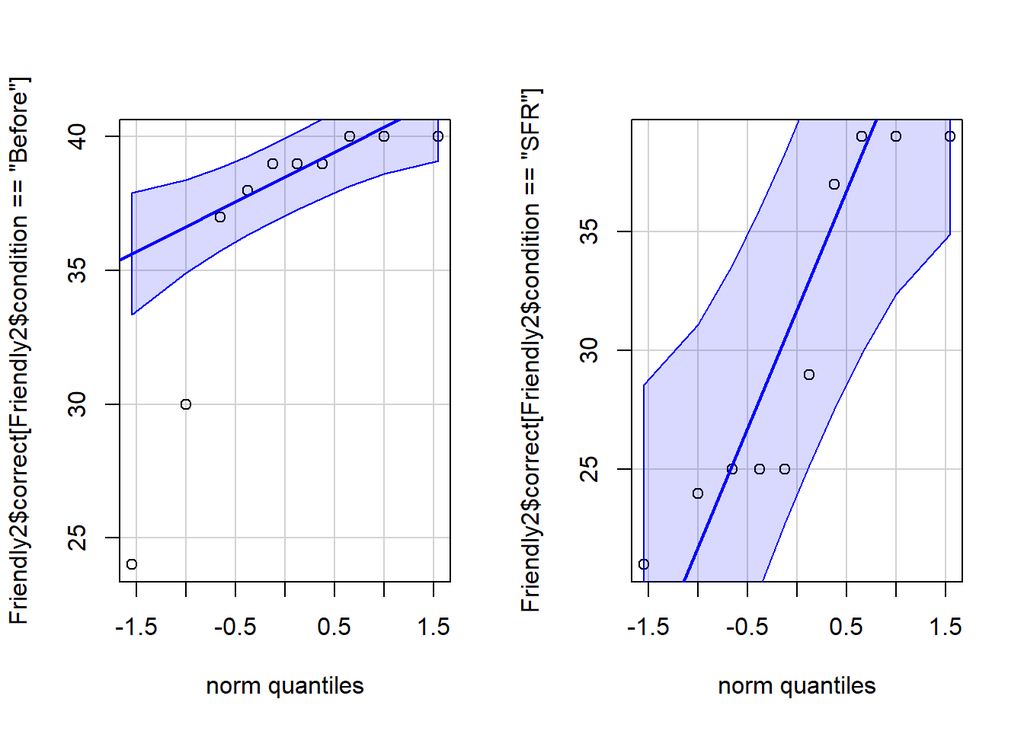

```r
par(mfrow= c(1,2))
qqPlot(Friendly2$correct[Friendly2$condition == "Before"], id=FALSE)
qqPlot(Friendly2$correct[Friendly2$condition == "SFR"], id=FALSE)
```

Looking at the QQ-plots above the data doesn’t seem to be completely normal mostly focusing on the “Before” condition QQ plot. Due to this shy lack of normality and lack of the number of points we will default to a Wilcoxon test rather than a t-test.

### Wilcoxon Test

To determine if it is reasonable to infer that the hypothesis is valid in the full population I will use a *Wilcoxon Rank Sum Test*. In the Wilcoxon test the results are still valid and show sufficient evidence to reject the null hypothesis $(p=0.02278<α)$ .

```r
wilcox.test(correct ~ condition, data=Friendly2, mu = 0, alternative = "greater", conf.level = 0.95) %>% pander()
```

Wilcoxon rank sum test with continuity correction: `correct` by `condition`

| Test statistic | P value | Alternative hypothesis |
| --- | --- | --- |
| 76.5 | 0.02278 * | greater |

### Interpretation

The *Before* memorization method seems to be more effective than the random method.